# Behavioural Data Analysis - EP3Dageing

Author

Kate Nevin

## Setting up the Document

**Show R code**

```r
if (!requireNamespace("here", quietly = TRUE)) install.packages("here")
library(here)

# sanity check: prints the project root
message("Project root: ", here::here())
```

**Show R code**

```r
# List of required packages
packages <- c(
  "tidyverse",
  "dplyr",
  "tidyr",
  "ggplot2",
  "psycho"        # Used for calculating hits, misses, etc. and d'
)

# Install missing packages
installed <- packages %in% rownames(installed.packages())
if (any(!installed)) {
  install.packages(packages[!installed])
}

# Load packages
invisible(lapply(packages, library, character.only = TRUE))
```

## Import Raw Data

### Set data directory

**Show R code**

```r
behavioural_data_dir <- here(
  "2. Raw Data and Videos",
  "1. Behavioural_Data"
)
```

### Import Data

**Show R code**

```r
# List all CSV files in the directory
behavioural_files <- list.files(
  path = behavioural_data_dir,
  pattern = "\\.csv$",
  full.names = TRUE
)

length(behavioural_files)
```

```
[1] 15
```

**Show R code**

```r
# Read in and process each file
behavioural_list <- lapply(behavioural_files, function(file) {
  df <- read_csv(file, show_col_types = FALSE) %>%
    select(-matches("^\\.\\.\\.\\d+$"))  # drop unnamed columns (...1, ...2, etc.)

  if ("occupation_task_hours" %in% names(df)) {
    df <- df %>% mutate(occupation_task_hours = as.character(occupation_task_hours))
  }

  if ("num_years_instrument" %in% names(df)) {
    df <- df %>% mutate(num_years_instrument = as.character(num_years_instrument))
  }

  if ("group" %in% names(df)) {
    df <- df %>% mutate(group = as.character(group))
  }

  if ("participant" %in% names(df)) {
    df <- df %>% mutate(participant = as.character(participant))
  }

  df
})

# Combine into one dataframe, recording which file each row came from
names(behavioural_list) <- basename(behavioural_files)
beh_df <- bind_rows(behavioural_list)
```

### Check Data Quality

**Show R code**

```r
head(beh_df)
```

```
# A tibble: 6 × 31
  participant group age_group DOB      age_yrs age_yrs_dec sex   education_level
  <chr>       <chr> <chr>     <chr>      <dbl>       <dbl> <chr> <chr>
1 164316      FALSE younger   15/06/2…      19        19.2 fema… secondary
2 164316      FALSE younger   15/06/2…      19        19.2 fema… secondary
3 164316      FALSE younger   15/06/2…      19        19.2 fema… secondary
4 164316      FALSE younger   15/06/2…      19        19.2 fema… secondary
5 164316      FALSE younger   15/06/2…      19        19.2 fema… secondary
6 164316      FALSE younger   15/06/2…      19        19.2 fema… secondary
# ℹ 23 more variables: hand_surgery_yn <chr>, hand_surgery_years_ago <dbl>,
#   occupation_hand_use_yn <chr>, occupation_tasks <chr>,
#   occupation_task_hours <chr>, num_languages <dbl>, languages_fluent <chr>,
#   musician_yn <chr>, instruments_played <chr>, num_years_instrument <chr>,
#   ref_stim <dbl>, comp_stim <dbl>, first_stim <dbl>, second_stim <dbl>,
#   trial_num <dbl>, step_size <dbl>, trial_type <chr>, key_resp <chr>,
#   corr <dbl>, first_dur <dbl>, second_dur <dbl>, isi_dur <dbl>, …
```

## Accuracy

### Overall Accuracy

**Show R code**

```r
mean_overall_accuracy <- mean(beh_df$corr)
mean_overall_accuracy
```

```
[1] 0.7305556
```

**Show R code**

```r
overall_accuracy_participant <- beh_df %>%
  group_by(participant) %>%
  summarise(mean = mean(corr),
            std = sd(corr))

knitr::kable(
  overall_accuracy_participant,
  col.names = c("Participant", "Mean", "Standard Deviation")
)
```

| Participant | Mean | Standard Deviation |
| --- | --- | --- |
| 164316 | 0.7500000 | 0.4423259 |
| 215259 | 0.5833333 | 0.5036102 |
| 222242 | 0.8333333 | 0.3806935 |
| 308775 | 0.7083333 | 0.4643056 |
| 480704 | 0.7916667 | 0.4148511 |
| 494115 | 0.5833333 | 0.5036102 |
| 523182 | 0.6666667 | 0.4815434 |
| 629768 | 0.5833333 | 0.5036102 |
| 690114 | 0.7916667 | 0.4148511 |
| 713565 | 0.7083333 | 0.4643056 |
| 808490 | 0.9583333 | 0.2041241 |
| 879560 | 0.7500000 | 0.4423259 |
| 908905 | 0.7083333 | 0.4643056 |
| 980339 | 0.7916667 | 0.4148511 |
| 999807 | 0.7500000 | 0.4423259 |

**Show R code**

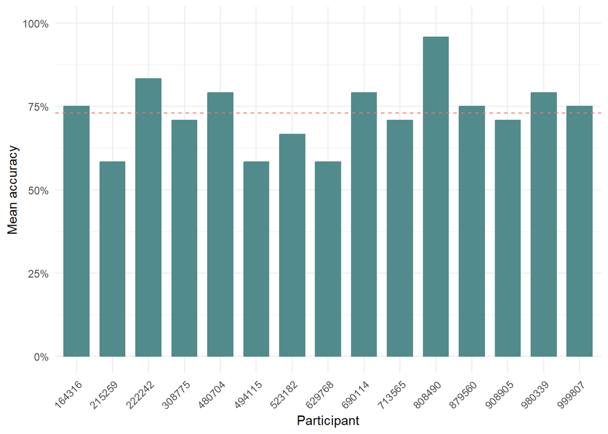

```r
ggplot(overall_accuracy_participant,
       aes(x = factor(participant), y = mean)) +
  geom_col(width = 0.7, col = "darkslategray4", fill = "darkslategray4") +
  scale_y_continuous(limits = c(0, 1), labels = scales::percent) +
  labs(x = "Participant", y = "Mean accuracy") +
  geom_hline(yintercept = mean(beh_df$corr), colour = "#F8766D", linetype = "dashed") +
  theme_minimal() +
  theme(axis.text.x = element_text(angle = 45, hjust = 1))
```

### Accuracy Same vs Different Trials

Overall accuracy per trial type (same trials versus different trials)

**Show R code**

```r
diff_accuracy <- mean(beh_df$corr[beh_df$trial_type == "diff"])
same_accuracy <- mean(beh_df$corr[beh_df$trial_type == "same"])
```

**Show R code**

```r
accuracy_same_diff_participant <- beh_df %>%
  group_by(participant, trial_type) %>%
  summarise(mean = mean(corr),
            std = sd(corr))

knitr::kable(
  accuracy_same_diff_participant,
  col.names = c("Participant", "Trial Type", "Mean", "Standard Deviation")
)
```

| Participant | Trial Type | Mean | Standard Deviation |
| --- | --- | --- | --- |
| 164316 | diff | 0.5000000 | 0.5222330 |
| 164316 | same | 1.0000000 | 0.0000000 |
| 215259 | diff | 0.7500000 | 0.4522670 |
| 215259 | same | 0.4166667 | 0.5149287 |
| 222242 | diff | 0.8333333 | 0.3892495 |
| 222242 | same | 0.8333333 | 0.3892495 |
| 308775 | diff | 0.6666667 | 0.4923660 |
| 308775 | same | 0.7500000 | 0.4522670 |
| 480704 | diff | 0.7500000 | 0.4522670 |
| 480704 | same | 0.8333333 | 0.3892495 |
| 494115 | diff | 0.5833333 | 0.5149287 |
| 494115 | same | 0.5833333 | 0.5149287 |
| 523182 | diff | 0.5833333 | 0.5149287 |
| 523182 | same | 0.7500000 | 0.4522670 |
| 629768 | diff | 0.5833333 | 0.5149287 |
| 629768 | same | 0.5833333 | 0.5149287 |
| 690114 | diff | 0.8333333 | 0.3892495 |
| 690114 | same | 0.7500000 | 0.4522670 |
| 713565 | diff | 0.6666667 | 0.4923660 |
| 713565 | same | 0.7500000 | 0.4522670 |
| 808490 | diff | 0.9166667 | 0.2886751 |
| 808490 | same | 1.0000000 | 0.0000000 |
| 879560 | diff | 0.7500000 | 0.4522670 |
| 879560 | same | 0.7500000 | 0.4522670 |
| 908905 | diff | 0.6666667 | 0.4923660 |
| 908905 | same | 0.7500000 | 0.4522670 |
| 980339 | diff | 0.5833333 | 0.5149287 |
| 980339 | same | 1.0000000 | 0.0000000 |
| 999807 | diff | 0.7500000 | 0.4522670 |
| 999807 | same | 0.7500000 | 0.4522670 |

**Show R code**

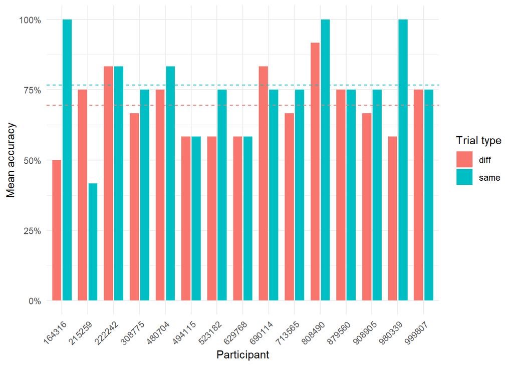

```r
ggplot(accuracy_same_diff_participant,
       aes(x = factor(participant), y = mean, fill = trial_type)) +
  geom_col(position = position_dodge(width = 0.8), width = 0.7) +
  scale_y_continuous(limits = c(0, 1), labels = scales::percent) +
  labs(x = "Participant", y = "Mean accuracy", fill = "Trial type") +
  geom_hline(yintercept = mean(beh_df$corr[beh_df$trial_type == "diff"]), colour = "#F8766D", linetype = "dashed") +
  geom_hline(yintercept = mean(beh_df$corr[beh_df$trial_type == "same"]), colour = "#00BFC4", linetype = "dashed") +
  theme_minimal() +
  theme(axis.text.x = element_text(angle = 45, hjust = 1))
```

## Hits, Misses, False Alarms, Correct Rejections

Now we need to calculate hits, misses, false alarms, and correct rejections. I am going define this in terms of “same” trials, i.e. a hit is the correct identification of a same trial.

**Show R code**

```r
signal_det <- beh_df %>%
  group_by(participant) %>%
  summarise(hits = sum(trial_type == "same" & key_resp == "s"),
            misses = sum(trial_type == "same" & key_resp == "d"),
            fa = sum(trial_type == "diff" & key_resp == "s"),
            corr_rej = sum(trial_type == "diff" & key_resp == "d")) %>%
  mutate(dprime = dprime(n_hit = hits,
                         n_miss = misses,
                         n_fa = fa,
                         n_cr = corr_rej)$dprime,
         c = dprime(n_hit = hits,
                    n_fa = fa,
                    n_miss = misses,
                    n_cr = corr_rej)$c)
```

**Show R code**

```r
knitr::kable(
  signal_det,
  col.names = c("Participant", "Hits", "Misses", "False Alarms", "Correct Rejections", "d'", "c")
)
```

| Participant | Hits | Misses | False Alarms | Correct Rejections | d’ | c |
| --- | --- | --- | --- | --- | --- | --- |
| 164316 | 12 | 0 | 6 | 6 | 1.7688250 | -0.8844125 |
| 215259 | 5 | 7 | 3 | 9 | 0.4211130 | 0.4045846 |
| 222242 | 10 | 2 | 2 | 10 | 1.7388475 | 0.0000000 |
| 308775 | 9 | 3 | 4 | 8 | 1.0108664 | -0.1097079 |
| 480704 | 10 | 2 | 3 | 9 | 1.4845649 | -0.1271413 |
| 494115 | 7 | 5 | 5 | 7 | 0.3880563 | 0.0000000 |
| 523182 | 9 | 3 | 5 | 7 | 0.8091692 | -0.2105565 |
| 629768 | 7 | 5 | 5 | 7 | 0.3880563 | 0.0000000 |
| 690114 | 9 | 3 | 2 | 10 | 1.4845649 | 0.1271413 |
| 713565 | 9 | 3 | 4 | 8 | 1.0108664 | -0.1097079 |
| 808490 | 12 | 0 | 1 | 11 | 2.9672047 | -0.2852227 |
| 879560 | 9 | 3 | 3 | 9 | 1.2302822 | 0.0000000 |
| 908905 | 9 | 3 | 4 | 8 | 1.0108664 | -0.1097079 |
| 980339 | 12 | 0 | 5 | 7 | 1.9628532 | -0.7873984 |
| 999807 | 9 | 3 | 3 | 9 | 1.2302822 | 0.0000000 |

**Show R code**

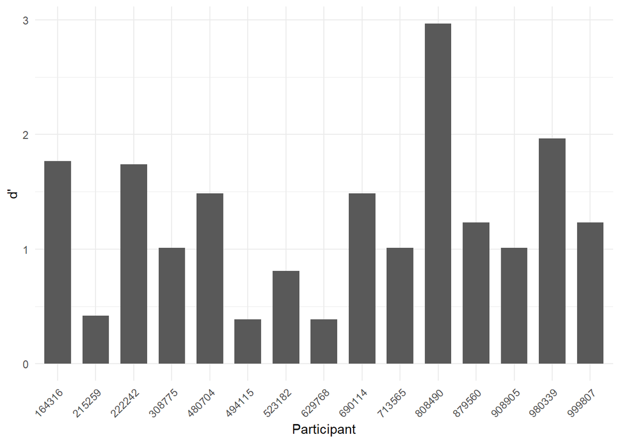

```r
ggplot(signal_det,
       aes(x = factor(participant), y = dprime)) +
  geom_col(position = position_dodge(width = 0.8), width = 0.7) +
  # scale_y_continuous(limits = c(0, 1), labels = scales::percent) +
  labs(x = "Participant", y = "d'") +
  theme_minimal() +
  theme(axis.text.x = element_text(angle = 45, hjust = 1))
```

**Show R code**

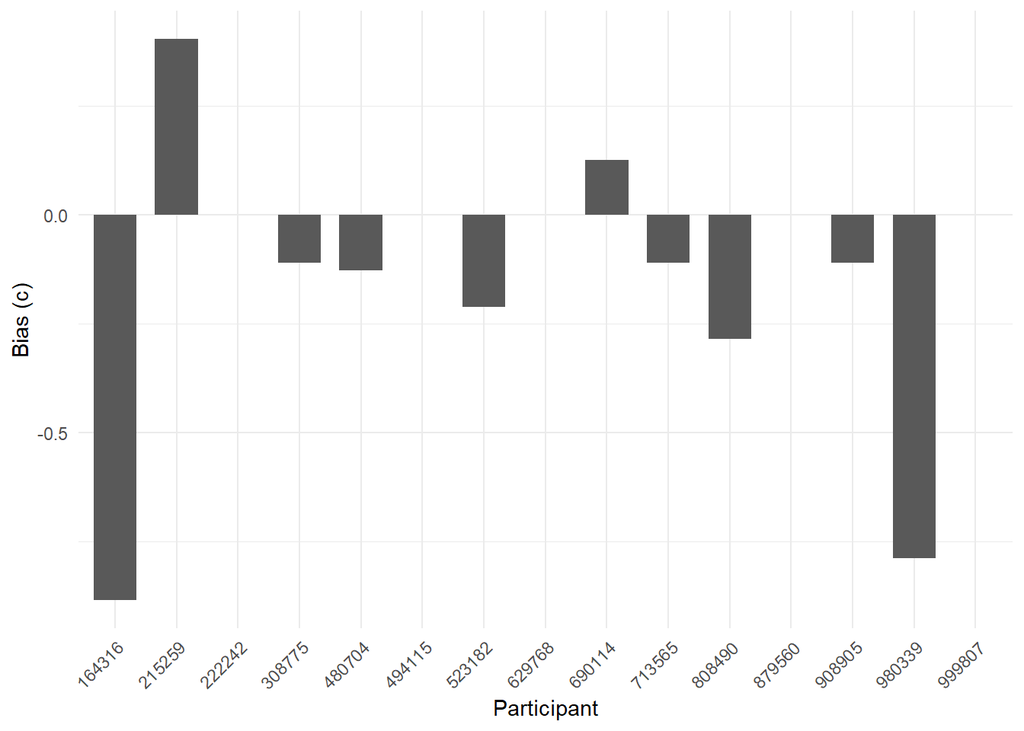

```r
ggplot(signal_det,
       aes(x = factor(participant), y = c)) +
  geom_col(position = position_dodge(width = 0.8), width = 0.7) +
  # scale_y_continuous(limits = c(0, 1), labels = scales::percent) +
  labs(x = "Participant", y = "Bias (c)") +
  theme_minimal() +
  theme(axis.text.x = element_text(angle = 45, hjust = 1))
```

### Compare same trials for improvement in the second exposure

Here I am going to see if participants get better in the second exposure to pairs of same objects

**Show R code**

```r
same_trials <- beh_df %>%
  filter(trial_type == "same")

# label first versus second presentation

same_trials_order_effects <- same_trials %>%
  group_by(participant, ref_stim, comp_stim) %>%
  arrange(trial_num, .by_group = TRUE) %>%
  mutate(repetition = factor(row_number(), labels = c("first", "second"))) %>%
  ungroup()

same_trials_order_effects %>% count(participant, ref_stim, comp_stim) %>% count(n)
```

```
# A tibble: 1 × 2
      n    nn
  <int> <int>
1     2    90
```

**Show R code**

```r
same_trials_order_effects
```

```
# A tibble: 180 × 32
   participant group age_group DOB     age_yrs age_yrs_dec sex   education_level
   <chr>       <chr> <chr>     <chr>     <dbl>       <dbl> <chr> <chr>
 1 164316      FALSE younger   15/06/…      19        19.2 fema… secondary
 2 164316      FALSE younger   15/06/…      19        19.2 fema… secondary
 3 164316      FALSE younger   15/06/…      19        19.2 fema… secondary
 4 164316      FALSE younger   15/06/…      19        19.2 fema… secondary
 5 164316      FALSE younger   15/06/…      19        19.2 fema… secondary
 6 164316      FALSE younger   15/06/…      19        19.2 fema… secondary
 7 164316      FALSE younger   15/06/…      19        19.2 fema… secondary
 8 164316      FALSE younger   15/06/…      19        19.2 fema… secondary
 9 164316      FALSE younger   15/06/…      19        19.2 fema… secondary
10 164316      FALSE younger   15/06/…      19        19.2 fema… secondary
# ℹ 170 more rows
# ℹ 24 more variables: hand_surgery_yn <chr>, hand_surgery_years_ago <dbl>,
#   occupation_hand_use_yn <chr>, occupation_tasks <chr>,
#   occupation_task_hours <chr>, num_languages <dbl>, languages_fluent <chr>,
#   musician_yn <chr>, instruments_played <chr>, num_years_instrument <chr>,
#   ref_stim <dbl>, comp_stim <dbl>, first_stim <dbl>, second_stim <dbl>,
#   trial_num <dbl>, step_size <dbl>, trial_type <chr>, key_resp <chr>, …
```

**Show R code**

```r
same_trials_order_effects %>%
  group_by(repetition) %>%
  summarise(mean_acc = mean(corr), sd = sd(corr), .groups = "drop")
```

```
# A tibble: 2 × 3
  repetition mean_acc    sd
  <fct>         <dbl> <dbl>
1 first         0.778 0.418
2 second        0.756 0.432
```

**Show R code**

```r
library(lme4)

m <- glmer(corr ~ repetition + (1 | participant) + (1 | ref_stim),
           data = same_trials_order_effects, family = binomial)
summary(m)
```

```
Generalized linear mixed model fit by maximum likelihood (Laplace
  Approximation) [glmerMod]
 Family: binomial  ( logit )
Formula: corr ~ repetition + (1 | participant) + (1 | ref_stim)
   Data: same_trials_order_effects

     AIC      BIC   logLik deviance df.resid
   201.1    213.9    -96.6    193.1      176

Scaled residuals:
    Min      1Q  Median      3Q     Max
-2.0925  0.3814  0.5105  0.5665  0.8254

Random effects:
 Groups      Name        Variance  Std.Dev.
 participant (Intercept) 3.583e-01 5.986e-01
 ref_stim    (Intercept) 1.736e-10 1.318e-05
Number of obs: 180, groups:  participant, 15; ref_stim, 6

Fixed effects:
                 Estimate Std. Error z value Pr(>|z|)
(Intercept)        1.3492     0.3129   4.311 1.62e-05 ***
repetitionsecond  -0.1319     0.3613  -0.365    0.715
---
Signif. codes:  0 '***' 0.001 '**' 0.01 '*' 0.05 '.' 0.1 ' ' 1

Correlation of Fixed Effects:
            (Intr)
repettnscnd -0.599
optimizer (Nelder_Mead) convergence code: 0 (OK)
boundary (singular) fit: see help('isSingular')
```

**Show R code**

```r
library(tidyr)

per_pp <- same_trials_order_effects %>%
  group_by(participant, repetition) %>%
  summarise(acc = mean(corr), .groups = "drop") %>%
  pivot_wider(names_from = repetition, values_from = acc)

wilcox.test(per_pp$second, per_pp$first, paired = TRUE)  # or t.test(..., paired = TRUE)
```

```
    Wilcoxon signed rank test with continuity correction

data:  per_pp$second and per_pp$first
V = 24, p-value = 0.7507
alternative hypothesis: true location shift is not equal to 0
```

Accuracy actually dipped slightly on the second exposure, however this does not come close to significance.

**Show R code**

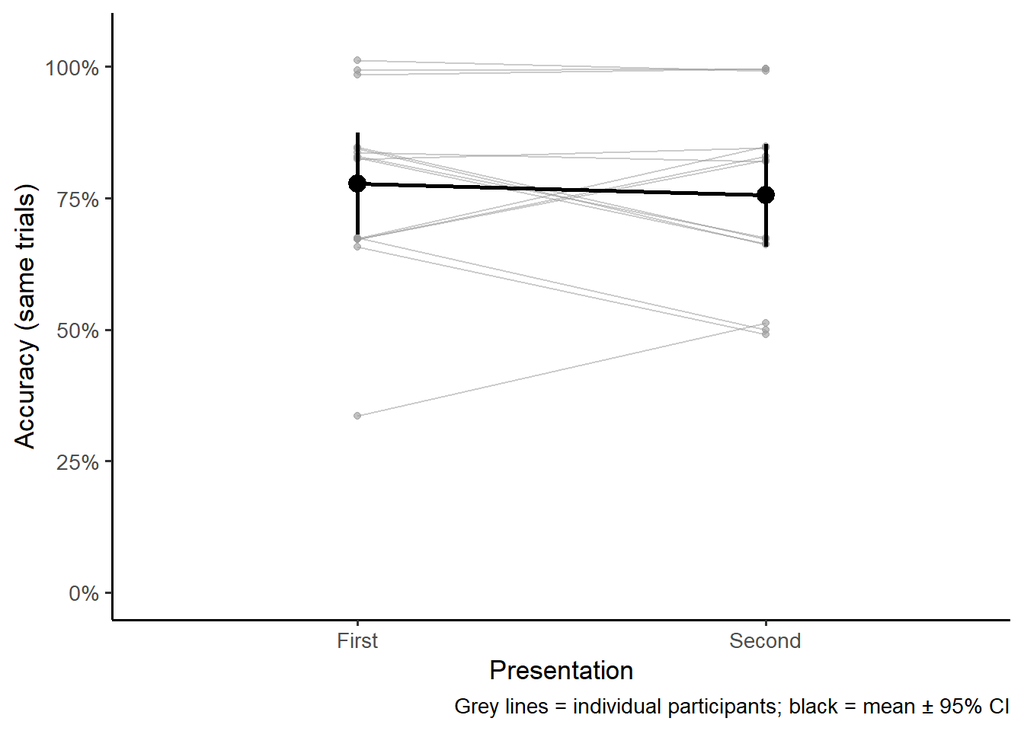

```r
per_pp_long <- same_trials_order_effects %>%
  group_by(participant, repetition) %>%
  summarise(acc = mean(corr), .groups = "drop")

summ <- per_pp_long %>%
  group_by(repetition) %>%
  summarise(mean = mean(acc),
            se = sd(acc) / sqrt(n()),
            lo = mean - qt(.975, n() - 1) * se,
            hi = mean + qt(.975, n() - 1) * se)

ggplot(per_pp_long, aes(x = repetition, y = acc)) +
  geom_line(aes(group = participant),
            colour = "grey60", alpha = 0.5,
            position = position_jitter(width = 0,
                                       height = 0.015,
                                       seed = 1)) +
  geom_point(colour = "grey60", alpha = 0.6,
             position = position_jitter(width = 0,
                                        height = 0.015,
                                        seed = 1)) +
  geom_pointrange(data = summ,
                  aes(y = mean,
                      ymin = lo,
                      ymax = hi),
                  color = "black",
                  size = 0.8,
                  linewidth = 1) +
  geom_line(data = summ,
            aes(y = mean,
                group = 1),
            linewidth = 1) +
  scale_y_continuous(limits = c(0, 1.05),
                     labels = scales::percent) +
  scale_x_discrete(labels = c("First", "Second")) +
  labs(x = "Presentation",
       y = "Accuracy (same trials)",
       caption = "Grey lines = individual participants; black = mean ± 95% CI") +
  theme_classic(base_size = 13)
```

## How does performance change over time?

Here I am going to plot performance by trail number per participant.

**Show R code**

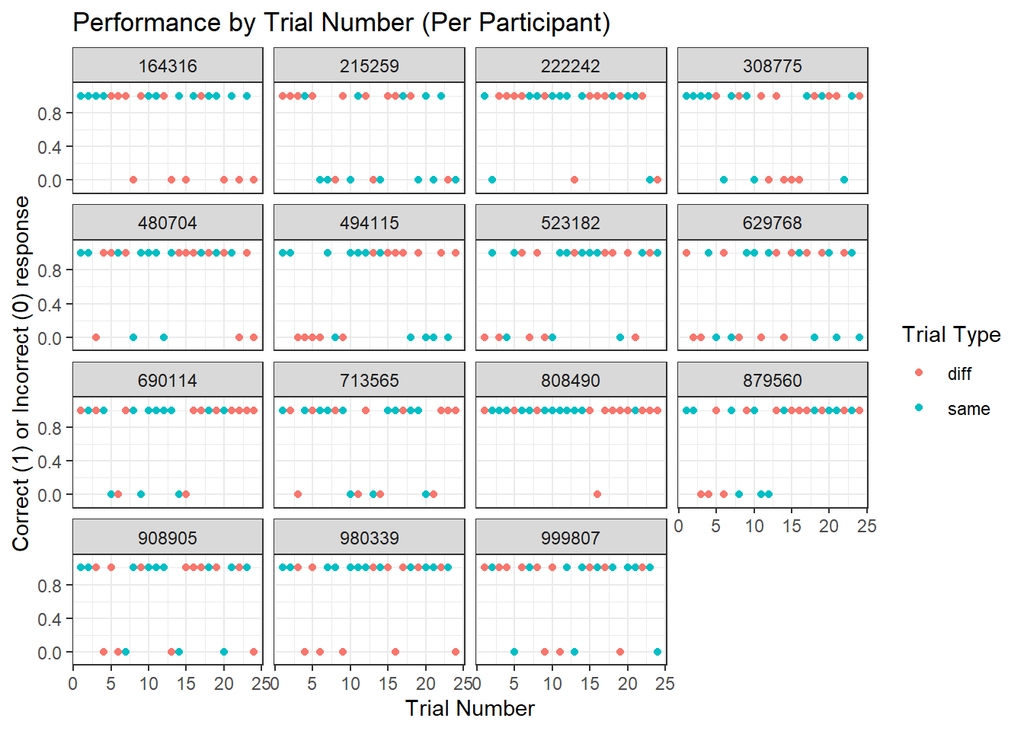

```r
ggplot(data = beh_df, aes(x = trial_num, y = corr, group = participant, colour = trial_type)) +
  geom_point() +
  facet_wrap(~participant) +
  labs(title = "Performance by Trial Number (Per Participant)",
       x = "Trial Number",
       y = "Correct (1) or Incorrect (0) response",
       colour = "Trial Type") +
  ylim(-0.1, 1.1) +
  theme_bw()
```